# 岡山大学 R講習 Rの基礎3

# グラフの重ね合わせ

geomプロットを重ねていくこともできます。重ね順は指定した順です。

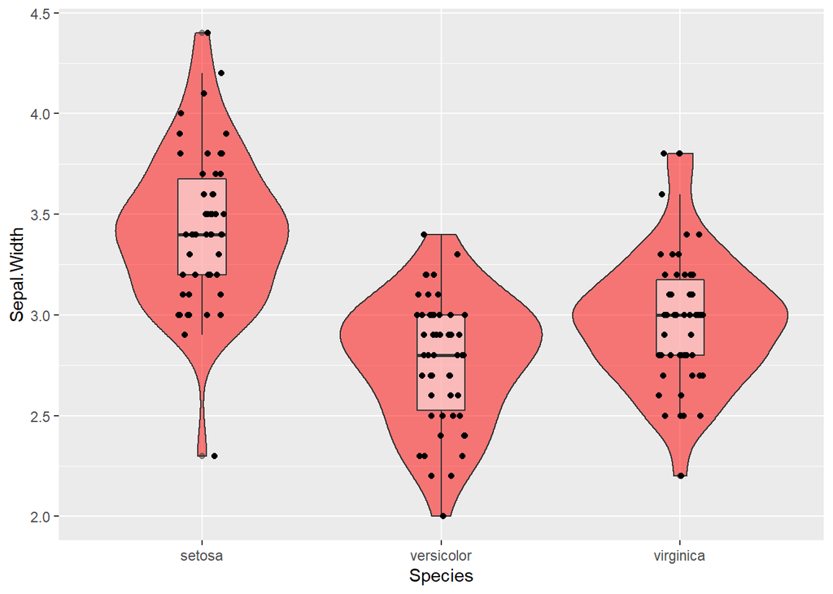

```r
ggplot(data = iris, aes(x = Species, y = Sepal.Width)) +
  geom_violin(fill = "red", alpha = 0.5) +
  geom_boxplot(width = 0.2, alpha = 0.5) +
  geom_jitter(height = 0, width = 0.1, shape = 19)
```

ちなみにplotをオブジェクトに保存することもできます。

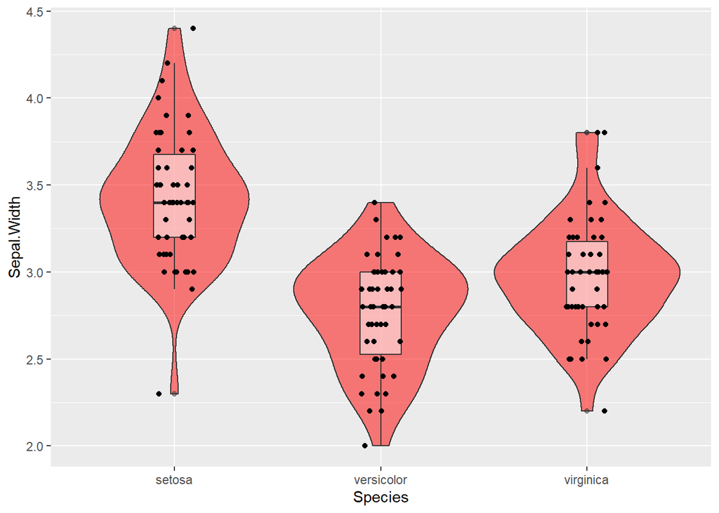

```r
p <- ggplot(data = iris, aes(x = Species, y = Sepal.Width))
# plotにさらにplotを足し算して重ねていくこともできます。
p1 <- p +  geom_violin(fill = "red", alpha = 0.5)
p2 <- p1 + geom_boxplot(width = 0.2, alpha = 0.5) +  geom_jitter(height = 0, width = 0.1, shape = 19)
p2
```

# 変数に沿ってグラフパラメーターを変化させる。

上記まではグラフのパラメーターを一様に変化させていましたが、データの群や、数値の大小に応じて色や透明度、サイズなどを変化させることができます。 これを応用すれば1つのプロットに多数の変数の情報を加えられます。

aesに変数を指定する必要があります。ggplotの中のaesでもgeom_の中のaesでもどちらでも構いません。

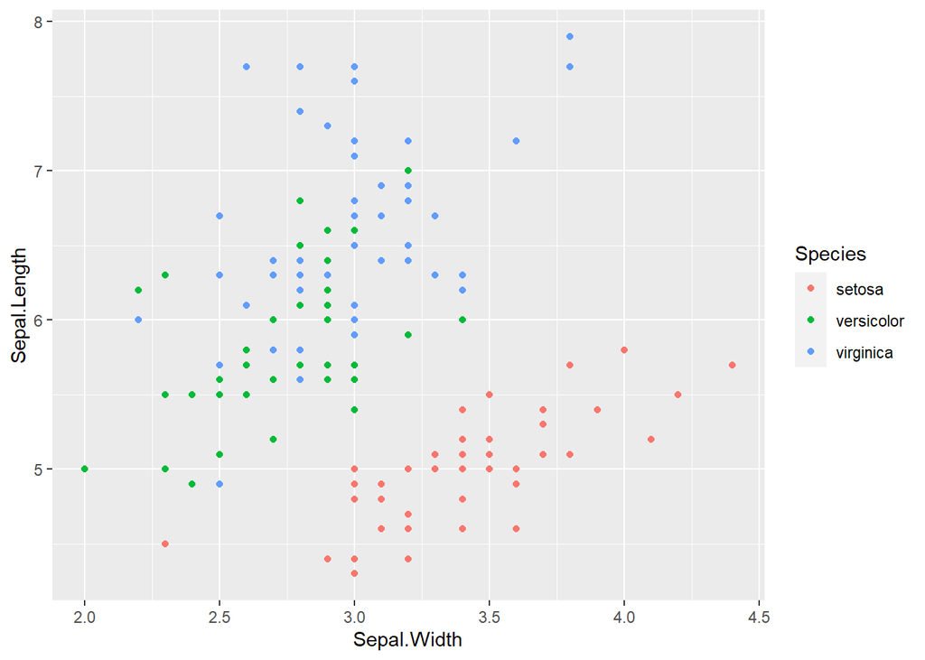

```r
# 散布図
ggplot(data = iris, mapping = aes(x = Sepal.Width, y = Sepal.Length, col = Species)) +
  geom_point()
```

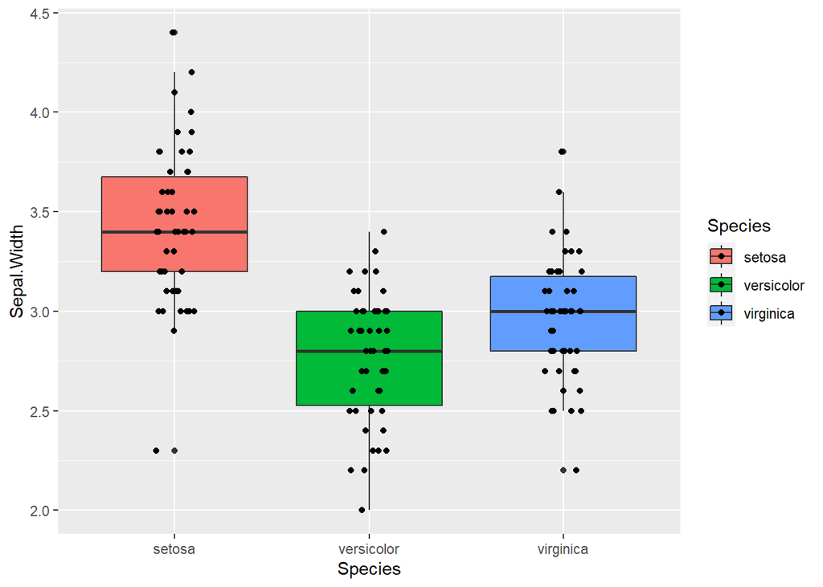

```r
ggplot(data = iris, aes(x = Species, y = Sepal.Width, fill = Species)) + geom_boxplot() + geom_jitter(height = 0, width = 0.1)
```

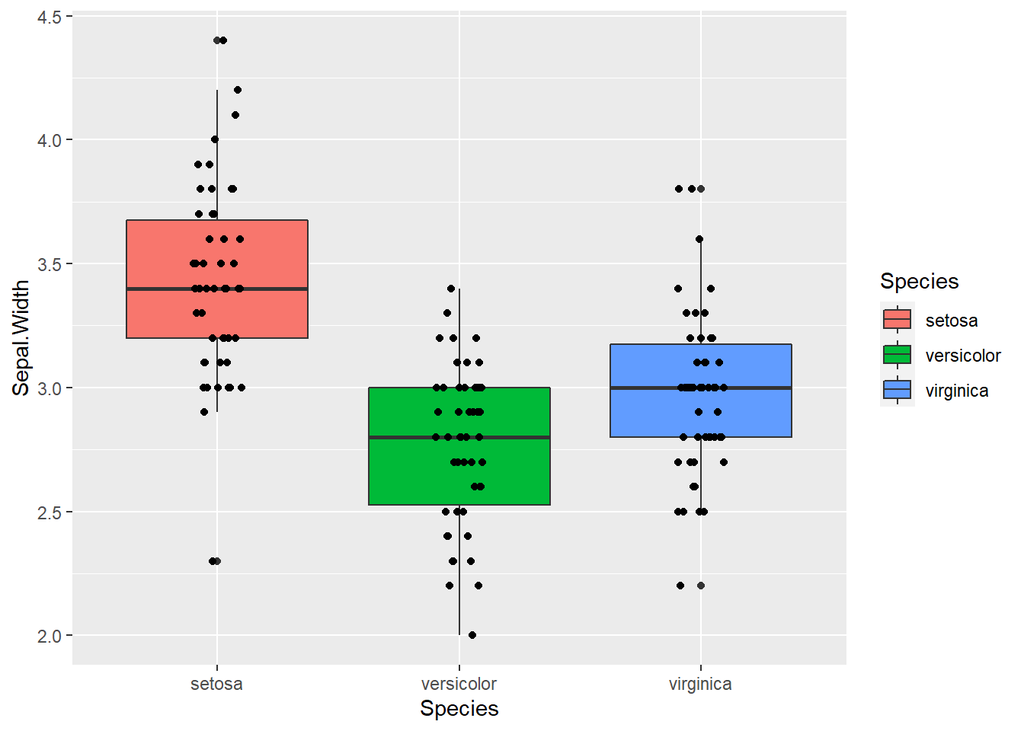

```r
ggplot(data = iris, aes(x = Species, y = Sepal.Width)) + geom_boxplot(aes(fill = Species)) + geom_jitter(height = 0, width = 0.1)
```

データフレームに含まれている列であれば、x軸y軸に指定されていない列であっても変数としてaesに指定することができます。  
以下ではSepal.Lengthの大小に応じて、色、透明度、ポイントサイズが変化するように指定してみました。

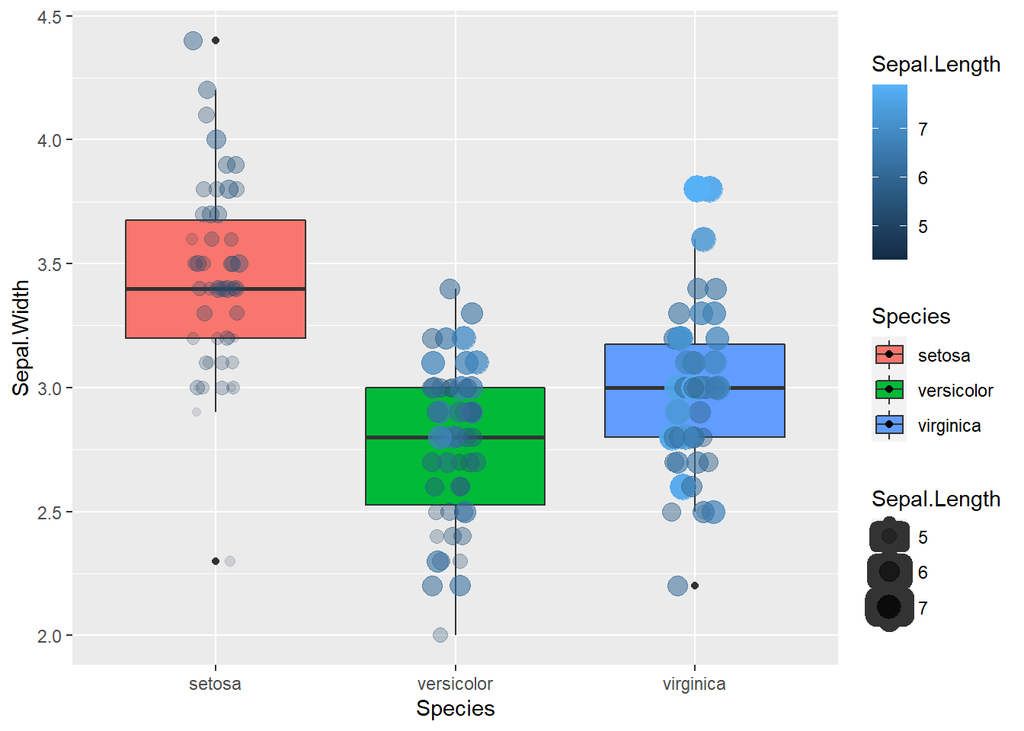

```r
ggplot(data = iris, aes(x = Species, y = Sepal.Width, fill = Species,
                        size = Sepal.Length, col = Sepal.Length, alpha = Sepal.Length)) +
  geom_boxplot() +
  geom_jitter(height = 0, width = 0.1)
```

## aesで指定可能な引数一覧

| 表現内容 | オプション | 例 |
| --- | --- | --- |
| 軸データを指定 | x, y, z | aes(x = 1, y = 2) |
| 塗りつぶしの色 | fill | aes(fill = “red”) |
| 線の色、囲み線の色 | colour | aes(colour = “red”) |
| 色の透過度 | alpha | aes(alpha = 0.5) |
| シンボルの形 | shape | aes(shape = 3) |
| シンボルのサイズ | size | aes(size = 4) |
| 線の種類 | linetype | aes(linetype = 1) |
| グループの指定 | group | aes(group = “読み込んだデータの列 or 行名”) |
| 並び替え | order | aes(order = “読み込んだデータの列 or 行名”) |
| x or yの最小値 | xmin or ymin | aes(xmin = 1) |
| x or yの最大値 | xmax or ymax | aes(xmax = 1) |
| 矢印の記入 | xend, yend, arrow | geom_segment(aes(x = 4, y = 25, xend = 3.5, yend = 20), arrow = arrow(length = unit(0.5, “cm”))) |

# 平均値±SDのグラフ

一般的なグラフは各データを個々にplotせずに、集計結果をplotします。  
そのためには、まず各群の平均値とSDを求めます。

```r
# Species列がsetosaの"行"を取り出す。
iris[ iris$Species == "setosa", ]
```

|  | Sepal.Length | Sepal.Width | Petal.Length | Petal.Width | Species |
| --- | --- | --- | --- | --- | --- |
| 1 | 5.1 | 3.5 | 1.4 | 0.2 | setosa |
| 2 | 4.9 | 3.0 | 1.4 | 0.2 | setosa |
| 3 | 4.7 | 3.2 | 1.3 | 0.2 | setosa |
| 4 | 4.6 | 3.1 | 1.5 | 0.2 | setosa |
| 5 | 5.0 | 3.6 | 1.4 | 0.2 | setosa |
| 6 | 5.4 | 3.9 | 1.7 | 0.4 | setosa |
| 7 | 4.6 | 3.4 | 1.4 | 0.3 | setosa |
| 8 | 5.0 | 3.4 | 1.5 | 0.2 | setosa |
| 9 | 4.4 | 2.9 | 1.4 | 0.2 | setosa |
| 10 | 4.9 | 3.1 | 1.5 | 0.1 | setosa |

[output cut: 40 more lines]

```r
# Species列がsetosaの"行"を取り出す。⇒ 集計したい列を1列指定し、ベクトルとして取り出す。
iris[ iris$Species == "setosa", "Sepal.Width"]
```

```
##  [1] 3.5 3.0 3.2 3.1 3.6 3.9 3.4 3.4 2.9 3.1 3.7 3.4 3.0 3.0 4.0 4.4 3.9 3.5 3.8
## [20] 3.8 3.4 3.7 3.6 3.3 3.4 3.0 3.4 3.5 3.4 3.2 3.1 3.4 4.1 4.2 3.1 3.2 3.5 3.6
## [39] 3.0 3.4 3.5 2.3 3.2 3.5 3.8 3.0 3.8 3.2 3.7 3.3
```

```r
# Species列がsetosaの"行"を取り出す。⇒ 集計したい列を1列指定し、ベクトルとして取り出す。 ⇒ これを集計する。
mean(iris[ iris$Species == "setosa", "Sepal.Width"])
```

```
## [1] 3.428
```

```r
sd(iris[ iris$Species == "setosa", "Sepal.Width"])
```

```
## [1] 0.3790644
```

これを繰り返してSpeciesのカテゴリごとに集計したデータフレームを作成

```r
# Speciesごとに取得した平均値をc()でつなげたベクトル作成
Sepal.Width_means <- c(mean(iris[ iris$Species == "setosa", "Sepal.Width"]),
                       mean(iris[ iris$Species == "versicolor", "Sepal.Width"]),
                       mean(iris[ iris$Species == "virginica", "Sepal.Width"])
                       )
# Speciesごとに取得したSDをc()でつなげたベクトル作成
Sepal.Width_SD <- c(sd(iris[ iris$Species == "setosa", "Sepal.Width"]),
                    sd(iris[ iris$Species == "versicolor", "Sepal.Width"]),
                    sd(iris[ iris$Species == "virginica", "Sepal.Width"])
                    )

# ベクトル2つを使ってデータフレーム作成。data.frameを作る際に列名を予め設定。meanとsd列にする。
Sepal.Width_MeanSD <- data.frame(mean = Sepal.Width_means, sd = Sepal.Width_SD)
Sepal.Width_MeanSD
```

| mean | sd |
| --- | --- |
| 3.428 | 0.3790644 |
| 2.770 | 0.3137983 |
| 2.974 | 0.3224966 |

```r
# このままだとSpeciesの情報が無いので、追記
Sepal.Width_MeanSD$Species <- c("setosa", "versicolor", "virginica")
Sepal.Width_MeanSD
```

| mean | sd | Species |
| --- | --- | --- |
| 3.428 | 0.3790644 | setosa |
| 2.770 | 0.3137983 | versicolor |
| 2.974 | 0.3224966 | virginica |

Sepal.Widthの平均値、SDのデータフレームを使って棒グラフを作成

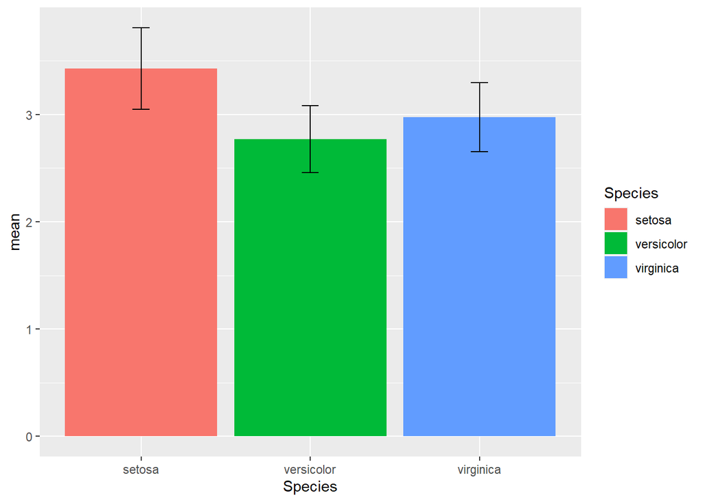

```r
ggplot(data = Sepal.Width_MeanSD, aes(x = Species, y = mean, fill = Species)) +
  geom_bar(stat = "identity") + # <-- geom_barを描く時のお決まり。

  # geom_errorbar機能でエラーバーを追記。aesにはy方向の最小値/最大値を指定する。
  geom_errorbar(aes(ymin = mean-sd, ymax = mean+sd), width = 0.1)
```

近年の研究論文ではn数が少ない場合は平均値±SDのグラフではなく、元データの分布もわかるようにdotplotを用いることが推奨されています。  
上記の棒グラフにdotplotも重ねてみます。  
※ ただし、棒グラフを描くためのデータフレームには個々のデータは含まれていませんので、dotplotを描く時にはデータフレームから再指定します。

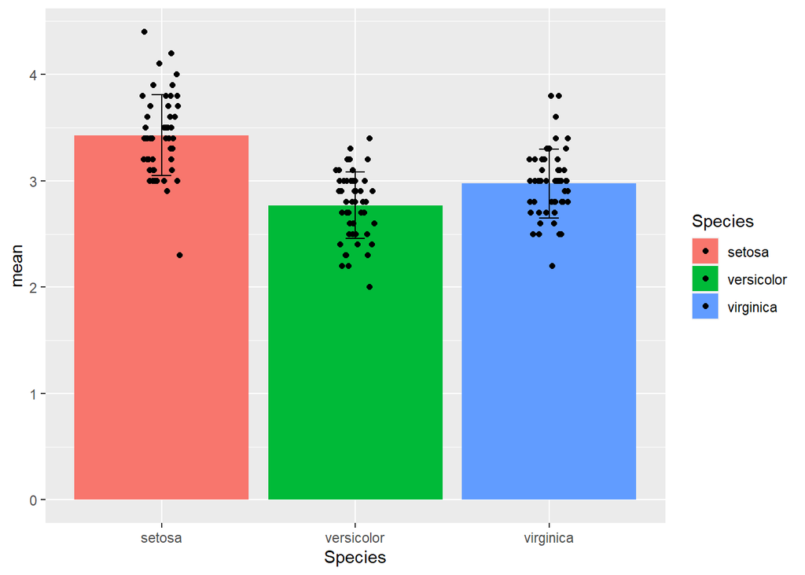

```r
ggplot(data = Sepal.Width_MeanSD, aes(x = Species, y = mean, fill = Species)) +
  geom_bar(stat = "identity") +
  geom_errorbar(aes(ymin = mean-sd, ymax = mean+sd), width = 0.1) +
  geom_jitter(data = iris, aes(x = Species, y = Sepal.Width), width = 0.1, height = 0)
```

## 実際のデータ成型 中級者向け

上記ではSpeciesのレベル (カテゴリ)ごとに集計を手入力しましたが、もっとレベルが増えた場合にいちいちタイプしてられません。

### tapplyでレベルごとに集計する方法。

引数となるベクトルオブジェクト(X =)に対して、同じ要素数のINDEXとなるベクトルを指定 (INDEX =)することでグループ化されます。  
その上で、グループごとに適応する機能をFUN = に指定します。

```r
tapply(X = iris$Sepal.Width, INDEX = iris$Species, FUN = mean)
```

```
##     setosa versicolor  virginica
##      3.428      2.770      2.974
```

```r
tapply(X = iris$Sepal.Width, INDEX = iris$Species, FUN = sd)
```

```
##     setosa versicolor  virginica
##  0.3790644  0.3137983  0.3224966
```

```r
data.frame(mean = tapply(X = iris$Sepal.Width, INDEX = iris$Species, FUN = mean),
           sd = tapply(X = iris$Sepal.Width, INDEX = iris$Species, FUN = sd))
```

|  | mean | sd |
| --- | --- | --- |
| setosa | 3.428 | 0.3790644 |
| versicolor | 2.770 | 0.3137983 |
| virginica | 2.974 | 0.3224966 |

### dplyrパッケージを使った集計法

dplyrはデータフレームの成型や集計を直感的に使えるパッケージです。使いこなすと楽です。

```r
install.packages("dplyr")
```

```r
library(dplyr)
```

dplyrパッケージを読み込むとパイプ記号( %>% )が使えるようになります。  
関数を複数使用すると、()の中に()を入れていく入れ子構造が複雑になり可読性が低下しますが、パイプ記号を用いれば関数の出力結果を次の関数の引数に使用できるため、左から右に関数が適応されている様子がわかりやすくなります。

```r
iris_mean_sd <- iris %>% group_by(Species) %>% summarise(mean = mean(Sepal.Width), sd = sd(Sepal.Width))
iris_mean_sd
```

| Species | mean | sd |
| --- | --- | --- |
| setosa | 3.428 | 0.3790644 |
| versicolor | 2.770 | 0.3137983 |
| virginica | 2.974 | 0.3224966 |

# plotの調整

変数に沿ったグラフパラメーターを微調整するにはscale_シリーズを使用します。  
scale_fill/col/alpha/size_〇〇などです。

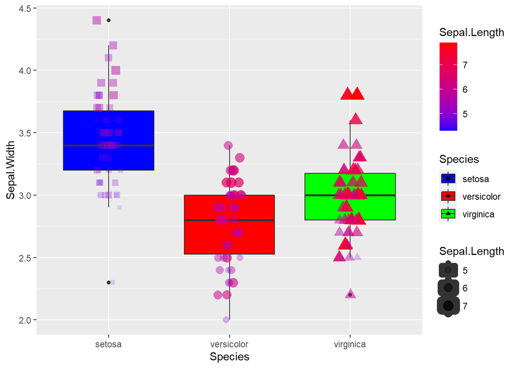

```r
ggplot(data = iris, aes(x = Species, y = Sepal.Width, fill = Species, shape = Species,
                        size = Sepal.Length, col = Sepal.Length, alpha = Sepal.Length)) +
  geom_boxplot() +
  geom_jitter(height = 0, width = 0.1) +
  scale_fill_manual(values = c("setosa" = "blue", "versicolor"="red", "virginica" ="green")) +
  # ↑↑ scale_〇〇_manualでは離散値の色を手打ちで指定します。"軸ラベル" = "色"で明示しても良いですし、"色"だけを軸順に指定するだけでも良いです。
  scale_color_gradient(low = "blue", high = "red") + # <-- scale_〇〇_gradient系は連続値のグラディエント色を調整できます。
  scale_size_continuous(range = c(1,5)) +
  scale_shape_manual(values = c(15,16,17))
```

グラフの軸の順番や表示域など

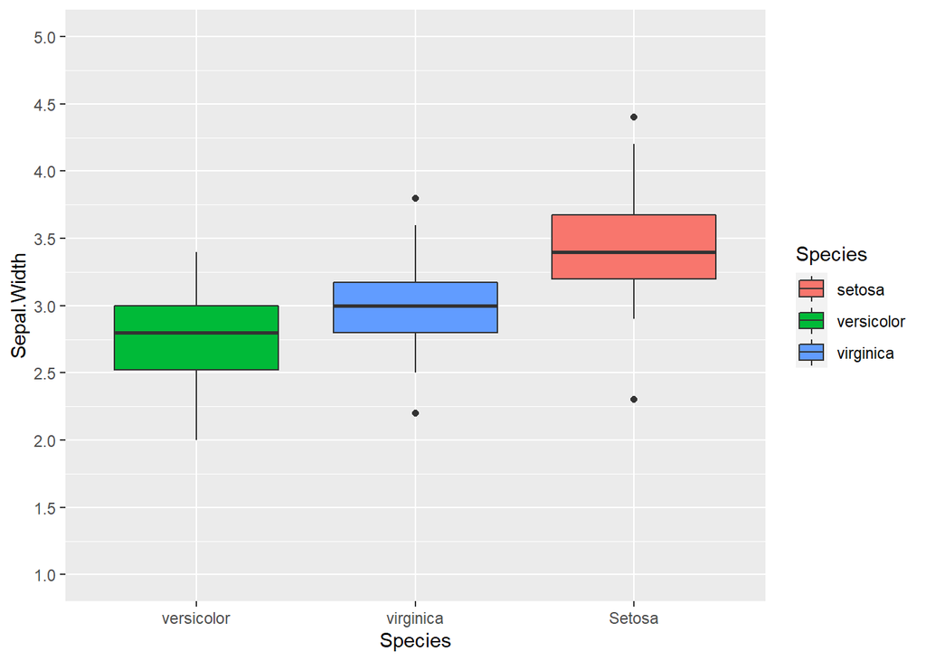

```r
ggplot(data = iris, aes(x = Species, y = Sepal.Width, fill = Species)) +
  geom_boxplot() +

  # scale_x/y_discreteで離散値軸の設定
  scale_x_discrete(limits = c("versicolor", "virginica", "setosa"), # <-- 軸の表示を制限したり、順番を指定したり
                   label = c("setosa" = "Setosa"), # <-- 軸ラベルの表示名を個々に変更したり。
                   ) +

  # scale_x/y_continuousで連続値軸の設定
  scale_y_continuous(limits = c(1,5), # <-- 表示範囲
                     breaks = seq(1,5,0.5)) # <-- 目盛り
```

### scale_()関数一覧

https://qiita.com/swathci/items/00b4a847843a33345887

| 軸 | 連続値 | 連続値のビン分割 | 離散値 | 離散値の手動設定 | 値そのまま |
| --- | --- | --- | --- | --- | --- |
| x | scale_x_ | scale_x_ | scale_x_ |  |  |
|  | continuous() | binned() | discrete() |  |  |
| y | scale_y_ | scale_y_ | scale_y_ |  |  |
|  | continuous() | binned() | discrete() |  |  |
| color | scale_color_ | scale_color_ | scale_color_ | scale_color_ | scale_color_ |
|  | continuous() | binned() | discrete() | manual() | identity() |
| colour | scale_colour_ | scale_colour_ | scale_colour_ | scale_colour_ | scale_colour_ |
|  | continuous() | binned() | discrete() | manual() | identity() |
| fill | scale_fill_ | scale_fill_ | scale_fill_ | scale_fill_ | scale_fill_ |
|  | continuous() | binned() | discrete() | manual() | identity() |
| alpha | scale_alpha_ | scale_alpha_ | scale_alpha_ | scale_alpha_ | scale_alpha_ |
|  | continuous() | binned() | discrete() | manual() | identity() |
| size | scale_size_ | scale_size_ | scale_size_ | scale_size_ | scale_size_ |
|  | continuous() | binned() | discrete() | manual() | identity() |
| shape |  | scale_shape_ | scale_shape_ | scale_shape_ | scale_shape_ |
|  |  | binned() | discrete() | manual() | identity() |
| linetype |  | scale_linetype_ | scale_linetype_ | scale_linetype_ | scale_linetype_ |
|  |  | binned() | discrete() | manual() | identity() |

|  | 連続値 | 連続値のビン分割 | 離散値 |
| --- | --- | --- | --- |
| 2色のグラデーション | scale_*_ | scale_*_ |  |
| (low-high) | gradient(low, high, ) | steps(low, high, ) |  |
| 3色のグラデーション | scale_*_ | scale_*_ |  |
| (low-mid-high) | gradient2(low, mid, high, | steps2(low, high, mid, |  |
|  | midpoint, ) | midpoint, ) |  |
| n色のグラデーション | scale_*_ | scale_*_ |  |
|  | gradientn(colors, ) | stepsn(colors, ) |  |
| グレースケール |  |  | scale_*_ |
|  |  |  | grey(start, end, ) |
| 色相hue |  |  | scale_*_ |
|  |  |  | hue(h, c, l, |
|  |  |  | direction = -1, ) |
| ColorBrewerパレット | scale_*_ | scale_*_ | scale_*_ |
|  | distiller(palette, | fermenter(palette, | brewer(palette, |
|  | direction = -1, ) | direction = -1, ) | direction = -1, ) |
| viridisLiteパレット | scale_*_ | scale_*_ | scale_*_ |
|  | viridis_c(option, | viridis_b(option, | viridis_d(option, |
|  | direction = -1, ) | direction = -1, ) | direction = -1, ) |

※ direction = -1で色順反転

## 図の体裁の調整

themeコマンドでグラフタイトルや軸ラベル、目盛線や凡例など細かな調整を行います。

一気にテーマを変更するようなtheme_シリーズも用意されています。

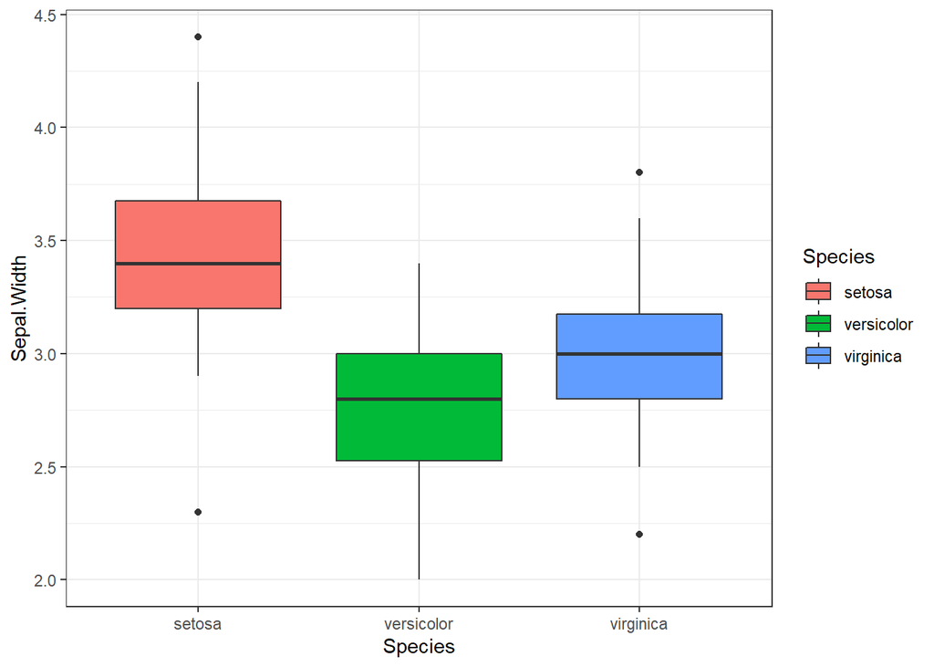

```r
ggplot(data = iris, aes(x = Species, y = Sepal.Width, fill = Species)) +
  geom_boxplot() +
  theme_bw() # 他にもtheme_classic() theme_dark() theme_light()などなど
```

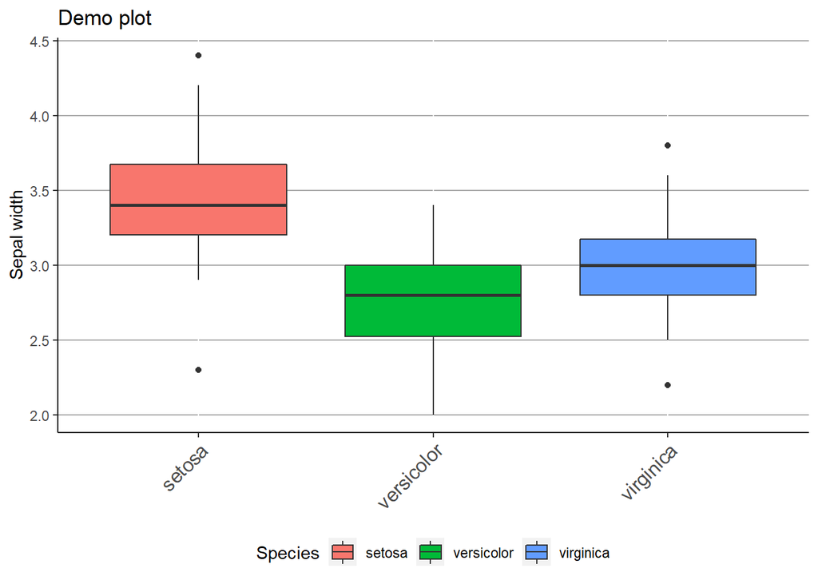

```r
ggplot(data = iris, aes(x = Species, y = Sepal.Width, fill = Species)) +
  geom_boxplot() +
  theme(axis.title.x = element_blank(), # <-- x軸ラベルを非表示
        axis.text.x = element_text(angle = 45, # <-- x軸ラベルの角度変更
                                   hjust = 1, vjust = 1, # <-- 角度を変えるとラベルの位置がずれるので調整
                                   size = 12 # <-- フォントサイズ
                                   ),
        legend.position = "bottom", # <-- 凡例の表示位置指定
        axis.line = element_line(color = "black"), # <-- 軸線の色変更
        panel.background = element_rect(fill = "transparent"), # <-- plotの背景色。
        panel.grid.major.y = element_line(colour = "darkgray") # <-- y軸の軸線の色変更
        ) +
  labs(title = "Demo plot", y = "Sepal width")
```

### themeコマンドの引数一覧

https://www.karada-good.net/analyticsr/r-78/

[output not shown]

# 統計量/統計解析をplotに反映する。stat_

plotに統計量を追加するにはstat_シリーズが使えます。  
箱ひげ図に平均値の点を加える。

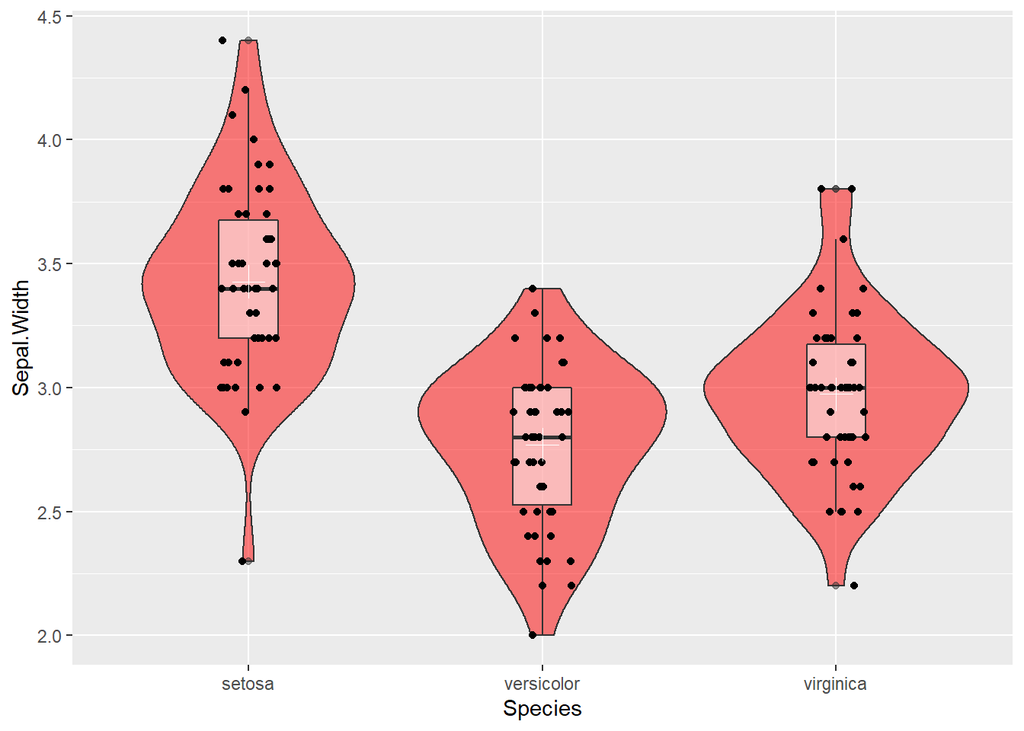

```r
ggplot(data = iris, aes(x = Species, y = Sepal.Width)) +
  geom_violin(fill = "red", alpha = 0.5) +
  geom_boxplot(width = 0.2, alpha = 0.5) +
  geom_jitter(height = 0, width = 0.1, shape = 19) +
  stat_summary(fun.y = "mean", geom = "point", col = "white", shape = 3, lwd = 5)
```

散布図に線形回帰の回帰式を追加。灰色の枠が95%信頼区間です。

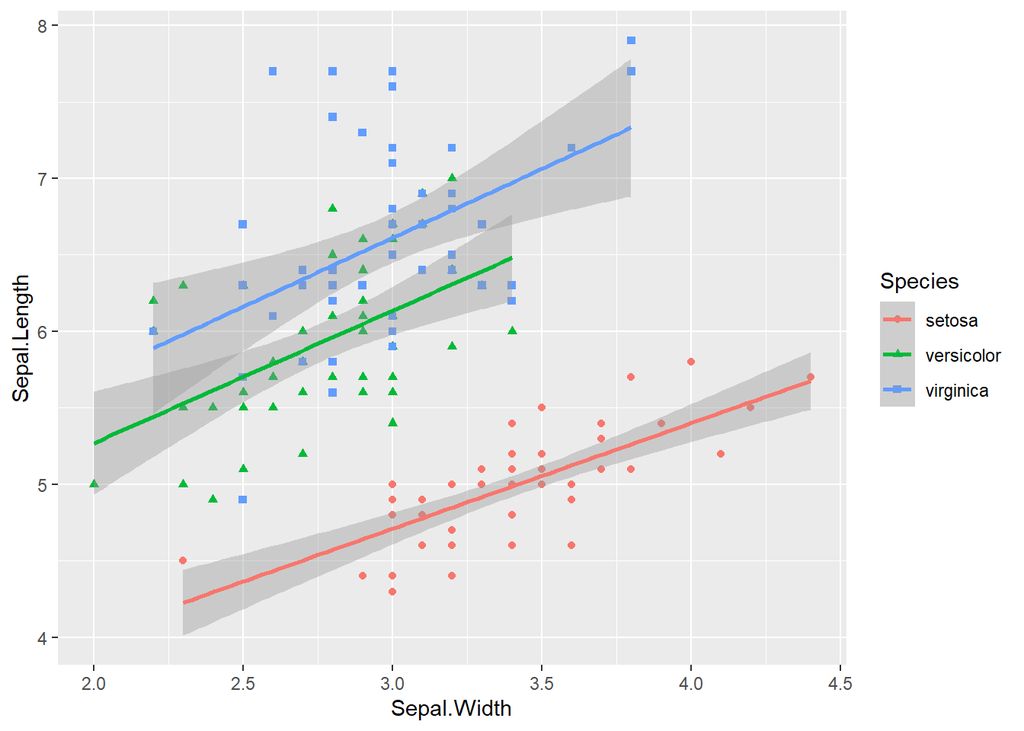

```r
ggplot(data = iris, mapping = aes(x = Sepal.Width, y = Sepal.Length, col = Species, shape = Species)) +
  geom_point() +
  stat_smooth(method = "lm")
```

### stat_(geom = )とgeom_(stat = )の一覧

| 変数の数 | xの型 | yの型 | zの型 | グラフ | stat_*() | geom_*() |
| --- | --- | --- | --- | --- | --- | --- |
| １変数 | 離散 |  |  | 棒グラフ | stat_count | geom_bar |
|  |  |  |  |  | (geom = “bar”, | (stat = “count”, |
|  |  |  |  |  | aes(y = ..count..)) | aes(y = ..count..)) |
|  |  |  |  | 折れ線グラフ | stat_count | geom_line |
|  |  |  |  |  | (geom = “line”, | (stat = “count”, |
|  |  |  |  |  | aes(y = ..count..)) | aes(y = ..count..)) |
|  |  |  |  |  | stat_count | geom_path |
|  |  |  |  |  | (geom = “path”, | (stat = “count”, |
|  |  |  |  |  | aes(y = ..count..)) | aes(y = ..count..)) |
|  |  |  |  | 面グラフ（エリアプロット） | stat_count | geom_area |
|  |  |  |  |  | (geom = “area”, | (stat = “count”, |
|  |  |  |  |  | aes(y = ..count..)) | aes(y = ..count..)) |
|  |  |  |  | マーカー付き折れ線グラフ | stat_count | stat_count |
|  |  |  |  |  | (geom = “line”, | (geom = “line”, |
|  |  |  |  |  | aes(y = ..count..)) + | aes(y = ..count..)) + |
|  |  |  |  |  | stat_count | stat_count |
|  |  |  |  |  | (geom = “point”, | (geom = “point”, |
|  |  |  |  |  | aes(y = ..count..)) | aes(y = ..count..)) |
|  | 連続 |  |  | ヒストグラム | stat_bin | geom_histogram |
|  |  |  |  |  | (geom = “bar”, | (stat = “bin”, |
|  |  |  |  |  | aes(y = ..count..)) | aes(y = ..count..)) |
|  |  |  |  |  |  | geom_bar |
|  |  |  |  |  |  | (stat = “bin”, |
|  |  |  |  |  |  | aes(y = ..count..)) |
|  |  |  |  | 度数曲線 |  | geom_freqpoly |
|  |  |  |  |  |  | (stat = “bin”, |
|  |  |  |  |  |  | aes(y = ..count..)) |
|  |  |  |  | ドットプロット |  | geom_dotplot |
|  |  |  |  |  |  | (binaxis = “x”) |
|  |  |  |  | 密度推定（線グラフ） | stat_density | geom_density |

[output cut: 108 more lines]

https://qiita.com/swathci/items/b08496d863bca4b479b3

## plotに有意差マークを付ける

書き方は幾つかありますので慣れたやり方で大丈夫です。 https://indenkun.hatenablog.com/entry/2020/08/13/233029

Sepal.WidthがSpeciesによって異なるのか、anova ⇒ Tukey_HSDで有意差を求める。

```r
Sepal.Width_stat <- TukeyHSD(aov(formula = Sepal.Width ~ Species, data = iris))
Sepal.Width_stat
```

```
##   Tukey multiple comparisons of means
##     95% family-wise confidence level
##
## Fit: aov(formula = Sepal.Width ~ Species, data = iris)
##
## $Species
##                        diff         lwr        upr     p adj
## versicolor-setosa    -0.658 -0.81885528 -0.4971447 0.0000000
## virginica-setosa     -0.454 -0.61485528 -0.2931447 0.0000000
## virginica-versicolor  0.204  0.04314472  0.3648553 0.0087802
```

geom_segmentを使って、線やアスタリスクの位置(x,y座標)を指定するのを1つずつ行うというのも一つのやり方。

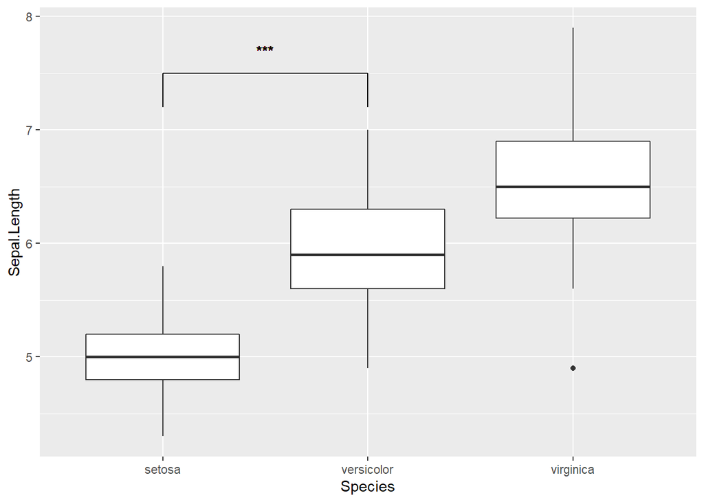

```r
ggplot(data = iris, mapping = aes(x = Species, y = Sepal.Length)) +
  geom_boxplot() +
  # setosaとverisicolorの2群の間(x = 1.5, y = 7.5)に有意差のマークをつける
  geom_text(x = 1.5, y = 7.7, label = "***") +
  # setosa(x = 1の座標)のグラフ上ちょっと上(y = 7.5から7.2に)から縦線をちょっと引いて
  geom_segment(x = 1, xend = 1, y = 7.5, yend = 7.2) +
  # setosa(x = 1)からversicolor(x = 2)にさっき引いた直線(y = 7.5)とつながるように線を引いて
  geom_segment(x = 1, xend = 2, y = 7.5, yend = 7.5) +
  # Versicolor(x = 2)でグラフの上にちょっと直線をsetosa上に描いたのと同じ位置(y = 7.5から7.2)に描く
  geom_segment(x = 2, xend = 2, y = 7.5, yend = 7.2)
```

実際はそんなことやってられないので、統計解析結果から上手く有意差の記号をplotするパッケージを使用する。

まずrの基本統計コマンドの出力結果はデータ構造が複雑で、plotに使用するにはデータ成型が面倒。  
rstatixパッケージの統計出力を用いると便利。

```r
library(rstatix)
```

基本統計コマンドと類似した関数名が用意されており、出力結果はtibble型というデータフレームの一種が返される。

```r
Sepal.Width_stat <- tukey_hsd(x = iris, formula = Sepal.Width ~ Species) # <- ANOVAを結果を用いることも可能だが、データフレームをいきなり指定可能。
Sepal.Width_stat
```

|  | term | group1 | group2 | null.value | estimate | conf.low | conf.high | p.adj | p.adj.signif |
| --- | --- | --- | --- | --- | --- | --- | --- | --- | --- |
| 1 | Species | setosa | versicolor | 0 | -0.658 | -0.81885528 | -0.4971447 | 3.10e-14 | **** |
| 2 | Species | setosa | virginica | 0 | -0.454 | -0.61485528 | -0.2931447 | 1.36e-09 | **** |
| 3 | Species | versicolor | virginica | 0 | 0.204 | 0.04314472 | 0.3648553 | 8.78e-03 | ** |

この出力を使って、p値を表示する。ggpubrパッケージを使用する。

```r
library(ggpubr)
```

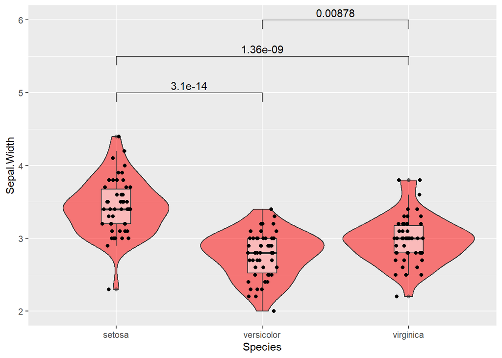

```r
ggplot(data = iris, aes(x = Species, y = Sepal.Width)) +
  geom_violin(fill = "red", alpha = 0.5) +
  geom_boxplot(width = 0.2, alpha = 0.5) +
  geom_jitter(height = 0, width = 0.1, shape = 19) +
  stat_pvalue_manual(data = Sepal.Width_stat,
                     y.position = c(5, 5.5, 6),  # <-- 有意差を表示する際のy軸位置を指定
                     label = "p.adj" # <-- rstatix結果のうち、どの列を表示に使用するか指定。p.adj.signifなら***などの記号。
                     )
```

便利なことにy軸の表示座標を自動で設定してくれる機能もある。

```r
Sepal.Width_stat <- add_y_position(Sepal.Width_stat)
Sepal.Width_stat
```

| term | group1 | group2 | null.value | estimate | conf.low | conf.high | p.adj | p.adj.signif | y.position | groups |
| --- | --- | --- | --- | --- | --- | --- | --- | --- | --- | --- |
| Species | setosa | versicolor | 0 | -0.658 | -0.81885528 | -0.4971447 | 3.10e-14 | **** | 4.52 |  |
| Species | setosa | virginica | 0 | -0.454 | -0.61485528 | -0.2931447 | 1.36e-09 | **** | 4.70 |  |
| Species | versicolor | virginica | 0 | 0.204 | 0.04314472 | 0.3648553 | 8.78e-03 | ** | 4.88 |  |

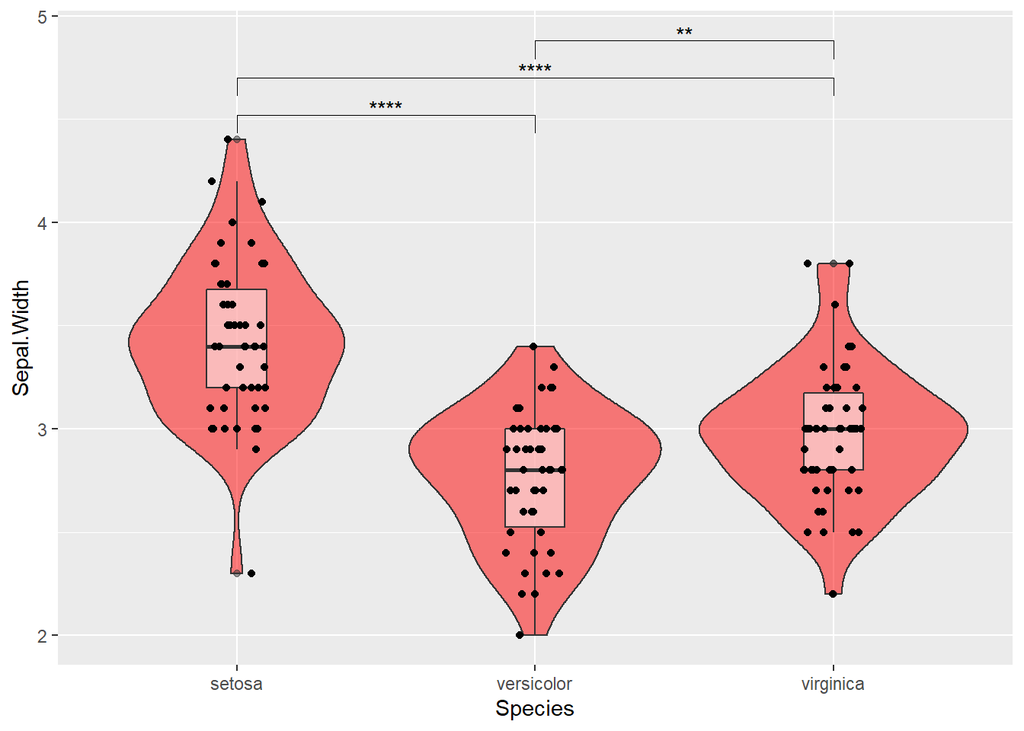

```r
ggplot(data = iris, aes(x = Species, y = Sepal.Width)) +
  geom_violin(fill = "red", alpha = 0.5) +
  geom_boxplot(width = 0.2, alpha = 0.5) +
  geom_jitter(height = 0, width = 0.1, shape = 19) +
  stat_pvalue_manual(data = Sepal.Width_stat,
                     label = "p.adj.signif"
                     )
```

※ 注意  
stat_pvalue_manualとaesでfillやcolなどを併用する場合は、ggplot()のaesに書かずに、geom_()の中のaesに書くこと。

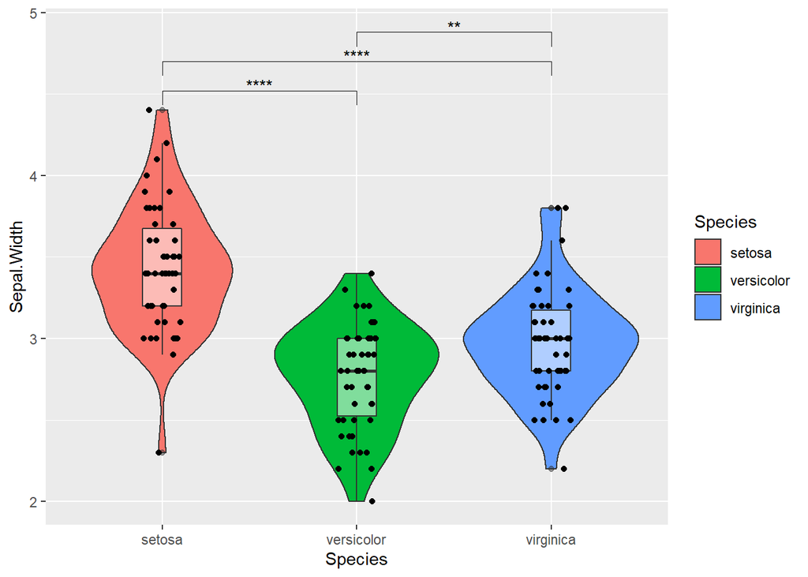

```r
ggplot(data = iris, aes(x = Species, y = Sepal.Width)) + # <----- ggplotのaesにはx, yぐらいにする。
   geom_violin(aes(fill = Species)) + # <----- geom_の中でaesを再設定
   geom_boxplot(width = 0.2, alpha = 0.5) +
   geom_jitter(height = 0, width = 0.1, shape = 19) +
   stat_pvalue_manual(data = Sepal.Width_stat,
                      label = "p.adj.signif"
                      )
```

stat_pvalue_manualのオプションを駆使するだけで論文Figができてしまう。 https://rpkgs.datanovia.com/ggpubr/reference/stat_pvalue_manual.html

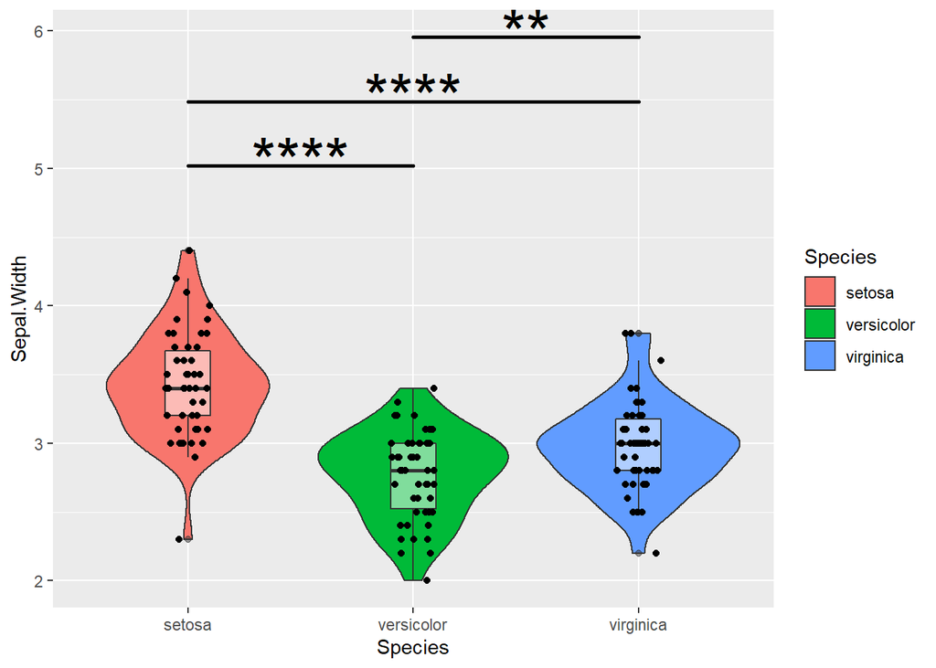

```r
p <- ggplot(data = iris, aes(x = Species, y = Sepal.Width)) +
  geom_violin(aes(fill = Species)) +
  geom_boxplot(width = 0.2, alpha = 0.5) +
  geom_jitter(height = 0, width = 0.1, shape = 19)
p + stat_pvalue_manual(data = Sepal.Width_stat,
                       label = "p.adj.signif", # 統計量のtibbleのどの列の内容を表示ラベルに使用するか
                       bracket.size = 1, # 線の太さ
                       bracket.nudge.y = 0.5, # データとの余白
                       size = 12, # ラベルの大きさ
                       color = "black",
                       tip.length = 0, # 下に伸びる線の長さ
                       step.increase = 0.1, # 有意差マークの間を段階的に開けていく
                       vjust = 0.5, # 線とラベルとの距離
                       hide.ns = T # nsの組み合わせを除く
                       )
```

残念ながら、ggolot2のgeom_barとは相性が悪くうまくいかない。  
geom_segmentなどggplot2のコマンドで一つずつ指定するか、ggpubrパッケージ内のplotコマンドを使用する。

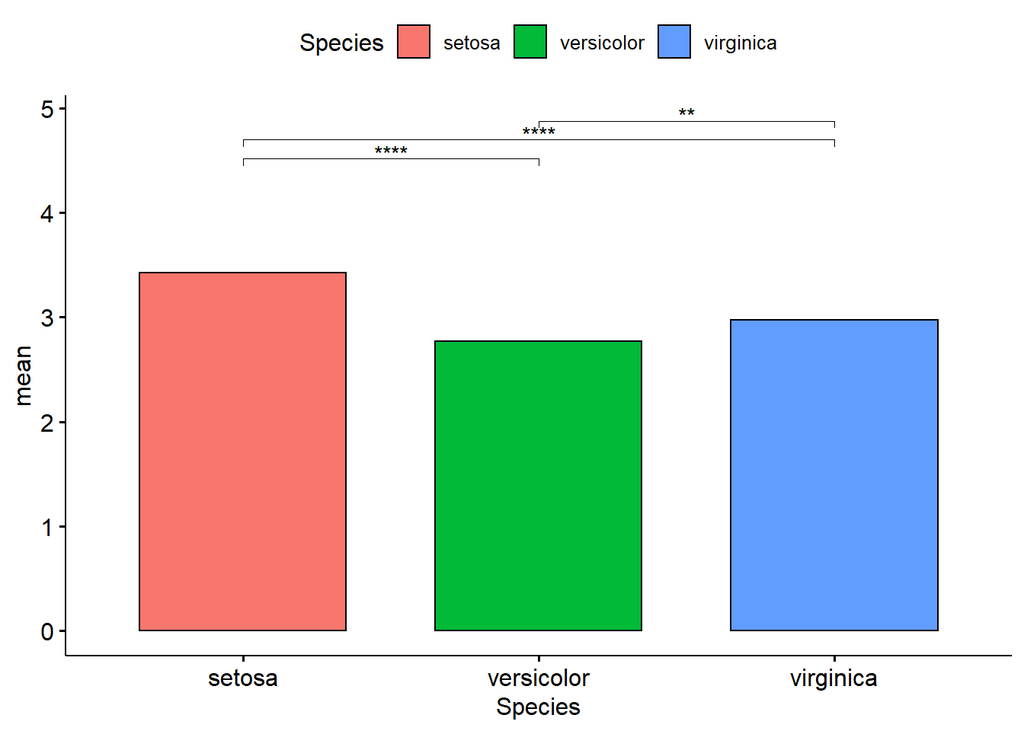

```r
ggbarplot(data = Sepal.Width_MeanSD, x = "Species", y = "mean", fill = "Species") +
  stat_pvalue_manual(data = Sepal.Width_stat)
```

ggpubrパッケージなら、meanとsdを計算したデータフレームを作成せずともadd =オプションで簡単に描画可能。

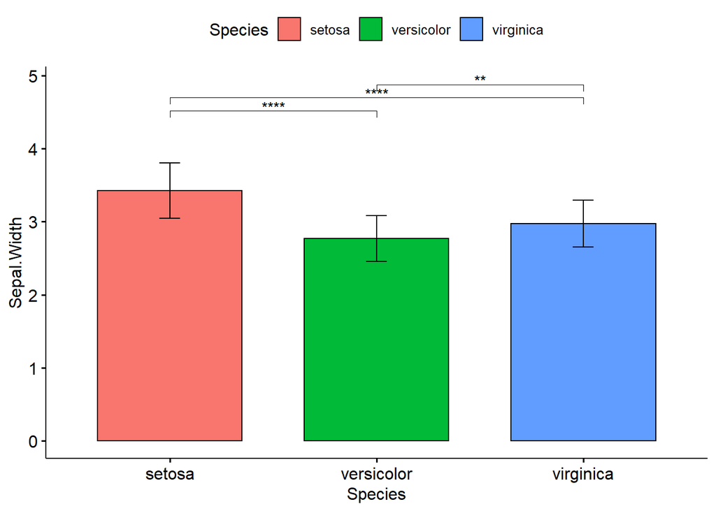

```r
ggbarplot(data = iris, x = "Species", y = "Sepal.Width", add = "mean_sd", fill = "Species") +
  stat_pvalue_manual(data = Sepal.Width_stat)
```

# 色

ggplot2のデフォルトとは異なる色パレットを搭載したパッケージをよく使用します。

```r
install.packages("RColorBrewer")
```

```r
library(RColorBrewer)
```

RColorBrewerパッケージのパレット一覧

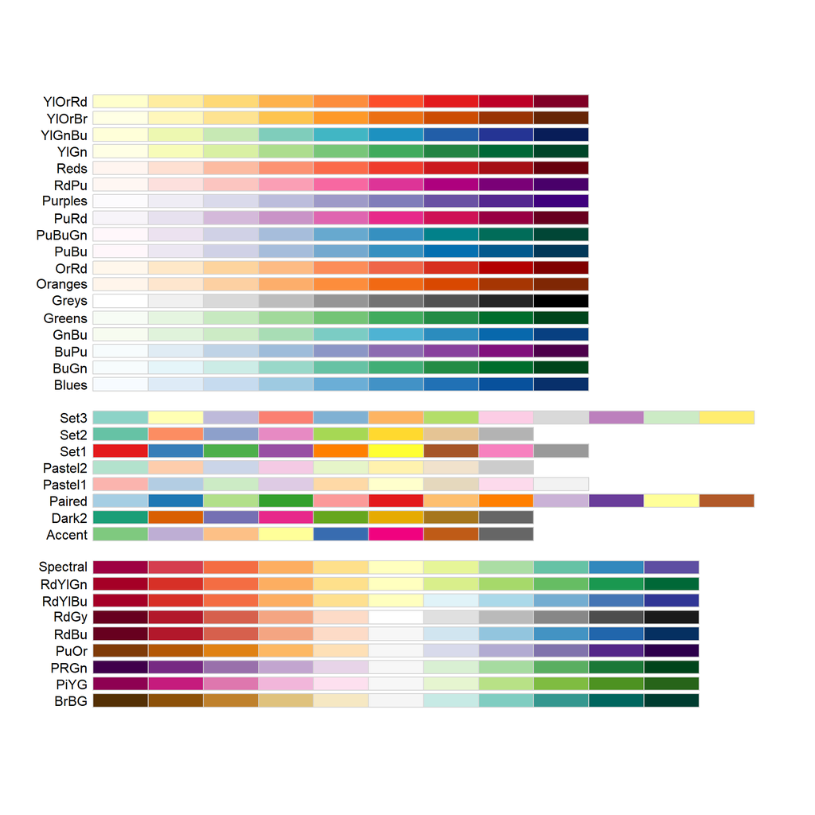

```r
display.brewer.all()
```

RColorBrewerから色ベクトルを取り出す。Set1から3色取り出す。

```r
brewer.pal(n = 3, name = "Set1")
```

```
## [1] "#E41A1C" "#377EB8" "#4DAF4A"
```

色はカラーコードで定義されています。redとかblueとか名前がついているものもありますが、redにもカラーコードがあります。

ggplotではRColorBrewerの色割り当て機能がついています。

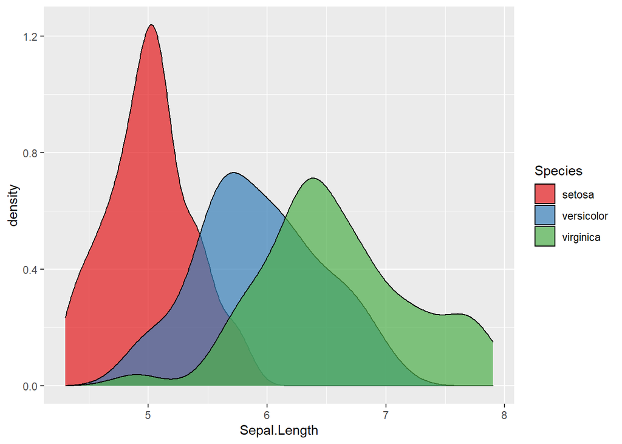

```r
ggplot(iris, aes(x = Sepal.Length, fill = Species)) + geom_density(alpha = 0.7) +
  scale_fill_brewer(palette = "Set1")
```

virdisパッケージもよく使用される色パッケージです。

```r
install.packages("viridis")
```

```r
library(viridis)
```

RColorBrewerよりも多くの色ベクトルを作成することができます。

```r
viridis(n = 100)
```

```
##   [1] "#440154FF" "#450558FF" "#46085CFF" "#470D60FF" "#471063FF" "#481467FF"
##   [7] "#481769FF" "#481B6DFF" "#481E70FF" "#482173FF" "#482576FF" "#482878FF"
##  [13] "#472C7AFF" "#472F7CFF" "#46327EFF" "#453581FF" "#453882FF" "#443B84FF"
##  [19] "#433E85FF" "#424186FF" "#404587FF" "#3F4788FF" "#3E4A89FF" "#3D4D8AFF"
##  [25] "#3C508BFF" "#3B528BFF" "#39558CFF" "#38598CFF" "#375B8DFF" "#355E8DFF"
##  [31] "#34608DFF" "#33638DFF" "#32658EFF" "#31688EFF" "#2F6B8EFF" "#2E6D8EFF"
##  [37] "#2D708EFF" "#2C718EFF" "#2B748EFF" "#2A768EFF" "#29798EFF" "#287C8EFF"
##  [43] "#277E8EFF" "#26818EFF" "#26828EFF" "#25858EFF" "#24878EFF" "#238A8DFF"
##  [49] "#228D8DFF" "#218F8DFF" "#20928CFF" "#20938CFF" "#1F968BFF" "#1F998AFF"
##  [55] "#1E9B8AFF" "#1F9E89FF" "#1FA088FF" "#1FA287FF" "#20A486FF" "#22A785FF"
##  [61] "#24AA83FF" "#25AC82FF" "#28AE80FF" "#2BB07FFF" "#2EB37CFF" "#31B67BFF"
##  [67] "#35B779FF" "#39BA76FF" "#3DBC74FF" "#41BE71FF" "#47C06FFF" "#4CC26CFF"
##  [73] "#51C56AFF" "#56C667FF" "#5BC863FF" "#61CA60FF" "#67CC5CFF" "#6DCD59FF"
##  [79] "#73D056FF" "#78D152FF" "#7FD34EFF" "#85D54AFF" "#8CD646FF" "#92D741FF"
##  [85] "#99D83DFF" "#A0DA39FF" "#A7DB35FF" "#ADDC30FF" "#B4DE2CFF" "#BBDE28FF"
##  [91] "#C2DF23FF" "#C9E020FF" "#D0E11CFF" "#D7E219FF" "#DDE318FF" "#E4E419FF"
##  [97] "#EBE51AFF" "#F1E51DFF" "#F7E620FF" "#FDE725FF"
```

virdisの色もggplotに登録されています。

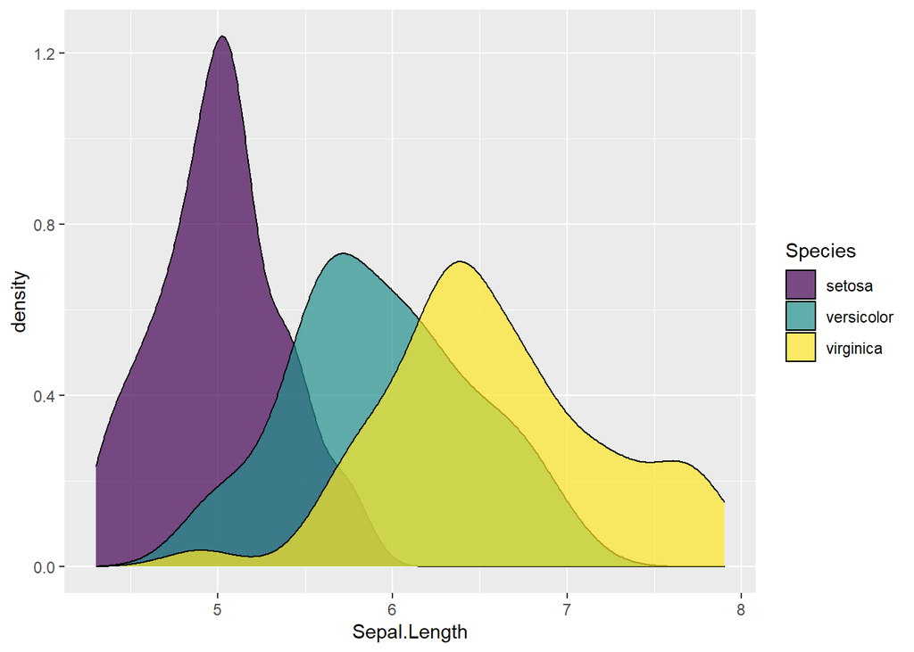

```r
ggplot(iris, aes(x = Sepal.Length, fill = Species)) + geom_density(alpha = 0.7) +
  scale_fill_viridis_d(option = "D") # optionから色パレット選択可能
```